# ECO634- Lab 9

Mercy Melo

11/10/2021

# Question 1

State the null hypothesis of the Chi-square test.

The null hypothesis of this Chi-square test is that Brown Creeper presence/absence does not follow the same distribution over edge/interior habitat that would be expected using randomized expected values.

# Question 2

Consider the results of your test and explain whether you think that Brown Creepers show a significant habitat preference.

My Chi-square test provided a significant p-value of 1.386e-06, which suggests that Brown Creepers do exhibit a habitat preference since their presence/absence strays from the expected values under the null hypothesis.

# Question 3

Show the R-code you can use to create a model fit (call it fit_species) of penguin body mass as predicted by penguin species.

```r
fit_species =
  lm(
    formula = body_mass_g ~ species,
    data = penguins)
```

# Question 4

Show the R-code you can use to create a model fit (call it fit_sex) of penguin body mass as predicted by sex.

```r
fit_sex =
  lm(
    formula = body_mass_g ~ sex,
    data = penguins)
```

# Question 5

Show the R-code you can use to create a model fit (call it fit_both) of penguin body mass as predicted by species and sex.

```r
fit_both =
  lm(
    formula = body_mass_g ~ species + sex,
    data = penguins)
```

# Question 6

Include a conditional boxplot corresponding to your fit_species model.

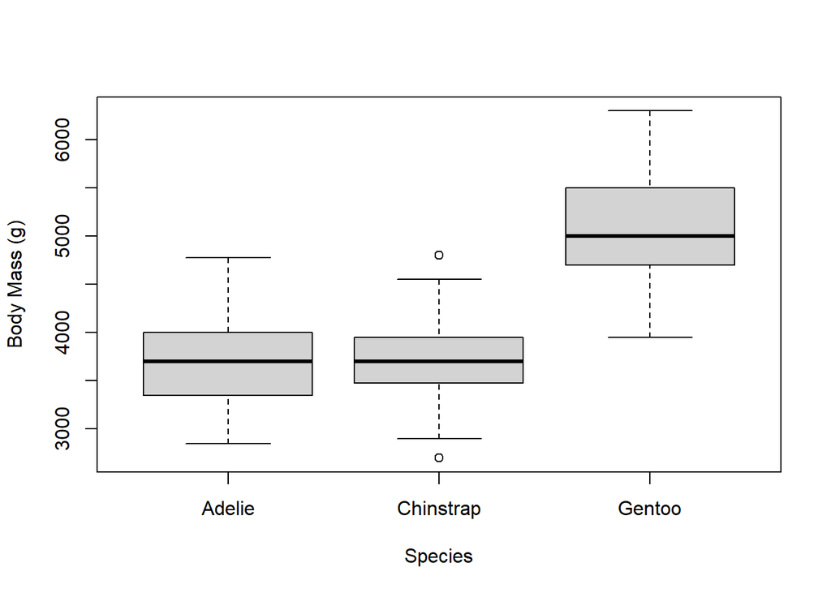

```r
boxplot(formula = body_mass_g ~ species,
        data = penguins,
        ylab = "Body Mass (g)",
        xlab = "Species")
```

# Question 7

Include a conditional boxplot corresponding to your fit_sex model.

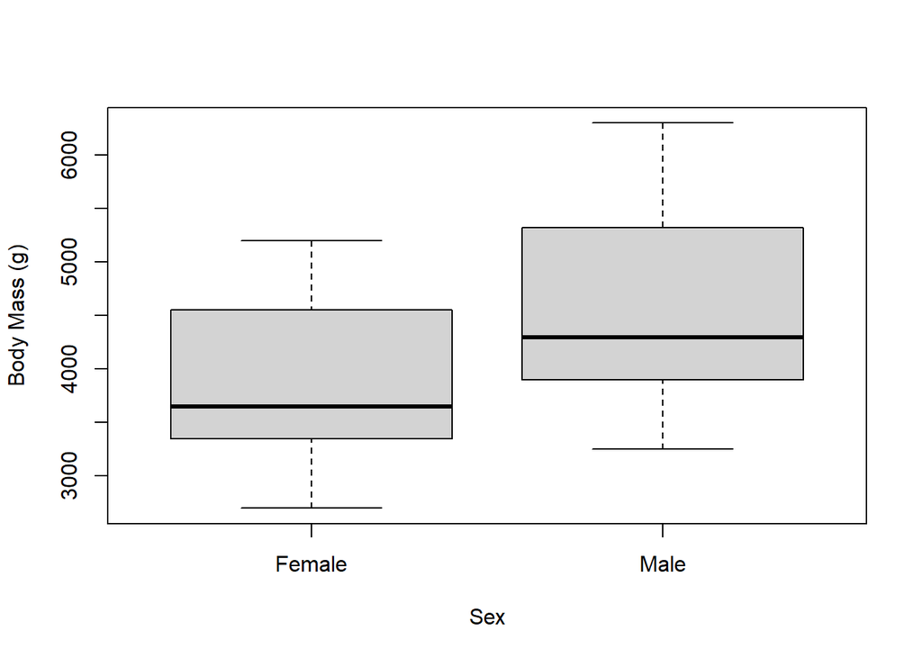

```r
boxplot(formula = body_mass_g ~ sex,
        data = penguins,
        ylab = "Body Mass (g)",
        xlab = "Sex",
        names = c("Female", "Male"))
```

# Question 8

Include a conditional boxplot corresponding to your fit_both model.

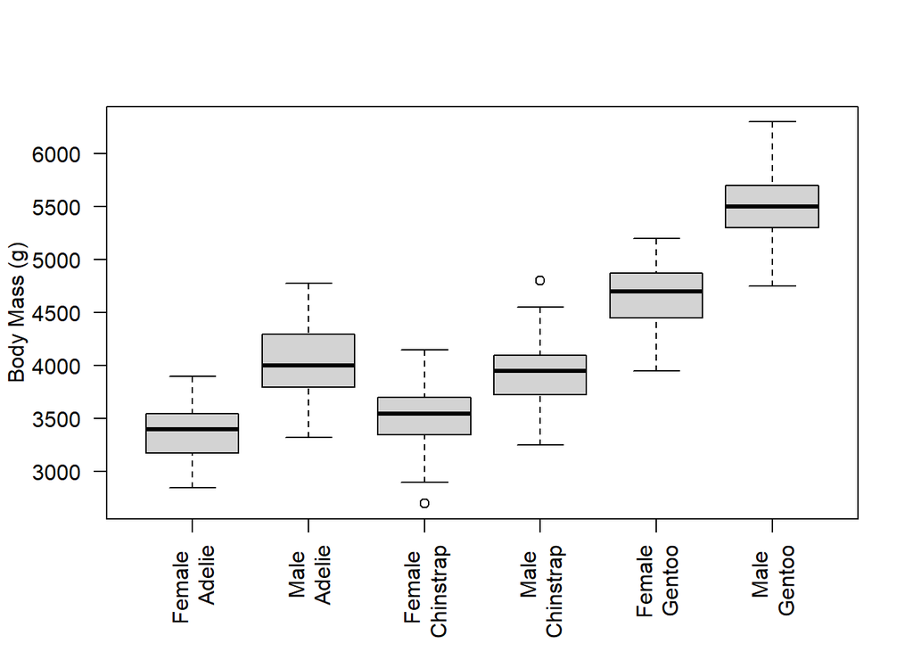

```r
boxplot(formula = body_mass_g ~ sex + species,
        data = penguins,
        ylab = "Body Mass (g)",
        xlab = " ",
        las = 2,
        names = c("Female \n Adelie", "Male \n Adelie",
                  "Female \n Chinstrap", "Male \n Chinstrap",
                  "Female\n Gentoo", "Male \n Gentoo"))
```

# Question 9

Based on the shapes of the boxes, which of the models (if any) do you think may have problems fulfilling the heterogeneity assumption?

# Question 10

State the null hypothesis of the Bartlett test.

The null hypothesis of the Bartlett test is that the variances within the groups being compared (the levels of the specified factor) are equal.

# Question 11

What was the p-value from the Bartlett test of homogeneity for observations grouped by species?

My p-value was 0.0501, which indicates that the groups have similar variances, but are close to being significantly different.

```r
bartlett.test(body_mass_g ~ species, data=penguins)
```

```
##
##  Bartlett test of homogeneity of variances
##
## data:  body_mass_g by species
## Bartlett's K-squared = 5.9895, df = 2, p-value = 0.05005
```

# Question 12

What was the p-value from the Bartlett test of homogeneity for observations grouped by sex?

My p-value was 0.0319, which indicates that the two sexes have different levels of variance.

```r
bartlett.test(body_mass_g ~ sex, data=penguins)
```

```
##
##  Bartlett test of homogeneity of variances
##
## data:  body_mass_g by sex
## Bartlett's K-squared = 4.6017, df = 1, p-value = 0.03194
```

# Question 13

What was the p-value from the Bartlett test of homogeneity for observations grouped by both factors?

My p-value was 0.1741, which indicates that variance within each of the groups is not significantly different.

```r
ss = aggregate(
  body_mass_g ~ species + sex,
  data = penguins,
  FUN = c)
str(ss)
```

```
## 'data.frame':    6 obs. of  3 variables:
##  $ species    : Factor w/ 3 levels "Adelie","Chinstrap",..: 1 2 3 1 2 3
##  $ sex        : Factor w/ 2 levels "female","male": 1 1 1 2 2 2
##  $ body_mass_g:List of 6
##   ..$ : int  3800 3250 3450 3625 3200 3700 3450 3325 3400 3800 ...
##   ..$ : int  3500 3525 3950 3250 4150 3800 3700 3575 3700 3450 ...
##   ..$ : int  4500 4450 4550 4800 4400 4650 4650 4200 4150 4800 ...
##   ..$ : int  3750 3650 4675 3800 4400 4500 4200 3600 3950 3800 ...
##   ..$ : int  3900 3650 3725 3750 3700 3775 4050 4050 3300 4400 ...
##   ..$ : int  5700 5700 5400 5200 5150 5550 5850 5850 6300 5350 ...
```

```r
bartlett.test(ss$body_mass_g)
```

```
##
##  Bartlett test of homogeneity of variances
##
## data:  ss$body_mass_g
## Bartlett's K-squared = 7.6908, df = 5, p-value = 0.1741
```

# Question 14

Based on the results of the Bartlett tests, do you anticipate any issues with heterogeneity in any of the models?

Yes, there may be issues of heterogeneity when using the model based on sex because the variances of males and females was statistically different. The other two Bartlett tests showed that variance was not significantly different between the groups, so you are not likely to incur issues of heterogeneity using those models.